# Scripts of the study ‘Transcriptional regulation of congocidine (netropsin) biosynthesis and resistance’, by Vingadassalon et al.

Stéphanie Bury-Moné

2021-06-11

# RNA-seq analysis

The datasets analyzed in this study have been deposited in the NCBI Gene Expression Omnibus (GEO, https://www.ncbi.nlm.nih.gov/geo/) under the accession number GSE162865.

## Mapping

STAR software (Dobin, A. *et al.*, 2013 - 2.7.7a version) was used for mapping RNA-seq to the reference genome containing only one terminal inverted repeat (TIR).

In the working directory, place:

- a subfolder ‘Fastq_files’ containing the fastq files;
- a subfolder ‘Bam_files’ which will contain the results;
- a subfolder ‘Genome’ which will contain the .fasta genome (‘GCF_001267885.1_ASM126788v1_genomic_woTIR2.fna’)

First activate the STAR module.

Create an index - Unix Script (from the working directory):

```
STAR   --runMode genomeGenerate   --runThreadN 4   --genomeDir ./Genome   --genomeFastaFiles ./Genome/GCF_001267885.1_ASM126788v1_genomic_woTIR2.fna      --genomeSAindexNbases 4
```

Mapping - Unix Script (from the working directory - example for one single ‘MP5-24h-1’ condition):

```
STAR --genomeDir ./Genome/ --runThreadN 4 --outFileNamePrefix ./Bam_files/MP5-24-1. --readFilesIn ./Fastq_files/MP5-24-1_S10_all_R1_001_cutadapt.fastq ./Fastq_files/MP5-24-1_S10_all_R2_001_cutadapt.fastq --outSAMtype BAM SortedByCoordinate --alignIntronMax 1000 --alignMatesGapMax 10000 --limitBAMsortRAM 1259563133
```

## Counting

We used the featureCounts program (Liao, Y. *et al.*, 2014; v2.0.1 version) to quantify reads in sense-orientation generated from RNA-sequencing technology in terms of “Gene” feature characteristics of *S. ambofaciens* ATCC 23877 annotation (GCF_001267885.1_ASM126788v1_genomic.gff – released on the 06/15/2020) that we manually curated to re-define the start positions of some *cgc* genes (*cgc1*, *cgc3*, *cgc4*, *cgc5*, *cgc6*, *cgc8* and *cgc10*), yeiling the “GCF_001267885.1_ASM126788v1_genomicCONGO.gff” annotation file.The strongest change concerns the start position of *cgc1* (shifted by 405 bp).

In the same working directory than for the mapping, create:

- a directory entitled “Annotation” containing the “GCF_001267885.1_ASM126788v1_genomicCONGO.gff” file
- a directory entitled “Counts”

Unix Script (example for one replicate - Please note that ‘-s 2’ correspond to the sense orientation in the dataset of interest):

```
featureCounts -p -s 2 -t gene -g ID -a ./Annotation/GCF_001267885.1_ASM126788v1_genomicCONGO.gff -T 4 -o ./Counts/MP5-24-1_counts_S.txt ./Bam_files/MP5-24-1.Aligned.sortedByCoord.out.bam
```

Counting - Unix Script (from the working directory - for all conditions):

```
sbatch script_featureCounts.sh
```

## DESeq2 analysis using SARTools

SARTools (Statistical Analysis of RNA-Seq data Tools - 1.7.3 version) DESeq2-based R pipeline (Varet, H *et al.*, 2016) was used for systematic quality controls and the detection of differentially expressed genes. PCA and sample clustering used homoscedastic data transformed with Variance Stabilizing Transformation (VST). For the differential analysis, the Benjamini and Hochberg’s method was used with a threshold of statistical significance adjusted to 0.05. The reference condition was ‘M_24h’ (24 h growth in MP5 medium). All parameters of SARTools that have default values were kept unchanged.

In the working directory, create a new directory named ‘DESeq2_analysis’. Put the ‘Target.txt’ file in ‘DESeq2_analysis’.

Script from a Unix console (the first command opens R, the rest of the script is R encoded):

```
R
```

R script:

[output not shown]

All the possible comparisons have been performed and are available in the “table” sub-directory generated in the “DESeq2-analysis” directory. For instance, the “M48hvsM24h.complete.txt” and “YCongo24hvsY24h.complete” files contain all statistical information concerning MP5-48h *versus* MP5-24h condition, and YEME10-24h-congo *versus* YEME10-24h condition comparisons, respectively.

We used these data to generate a table containing all information concerning the congocodine locus.

## References

Dobin, A. et al. STAR: ultrafast universal RNA-seq aligner. Bioinformatics 29, 15–21 (2013).

Liao, Y., Smyth, G. K. & Shi, W. featureCounts: an efficient general purpose program for assigning sequence reads to genomic features. Bioinformatics 30, 923–30 (2014).

Varet, H., Brillet-Gueguen, L., Coppee, J. Y. & Dillies, M. A. SARTools: A DESeq2- and EdgeR-Based R Pipeline for Comprehensive Differential Analysis of RNA-Seq Data. PLoS One 11, e0157022 (2016)

# Strong congocidine binding site counting

## Uploading the intergenic sequences

In the ‘Genome’ directory, place :

- the complete genome FASTA file, ‘GCF_001267885.1_ASM126788v1_genomic.fna’
- the ‘IR.gff’ file

The intergenic region gff (‘IR.gff’) was manually generated from the “GCF_001267885.1_ASM126788v1_genomicCONGO.gff” file, considering only the ‘genes’ (and not the pseudogenes) to identify the start and stop of intergenic regions (>3 bp) in the chromosome (NZ_CP012382.1) and pSAM1 plasmid (NZ_CP012383.1).

Bedtools (v2.29.2 version) was used to upload the intergenic region sequences using the complete genome fasta sequence (including both TIRs).

```
module load bedtools
bedtools getfasta -fi ./Genome/GCF_001267885.1_ASM126788v1_genomic.fna -bed ./Genome/IR.gff > IR_seq.txt
```

Thereafter, we generated the table ‘IR_seq.xlsx’ that can be easily proceeded by in R.

## Counting 4A/T patterns

The ‘IR_seq.xlsx’ file was imported in R from the working directory.

```r
library(readxl)
ALL <- read_excel("IR_seq.xlsx")
```

A function to count specific pattern was generated.

```r
motif.counter<-function(strings, pattern){
  counts<-NULL
  for(i in 1:length(strings)){
    counts[i]<-length(attr(gregexpr(pattern,strings[i])[[1]], "match.length")[attr(gregexpr(pattern,strings[i])[[1]], "match.length")>0])
  }
  return(counts)
}
```

With this function, once the pattern is counted, the corresponding sequence is excluded from any further counting. Thus in order to exclude a bias related to the order of searching for the patterns of interest (5’-AAAA-3’, 5’-TTTT-3’, 5’-AATT-3’), we tested all possible permutations of the 3 patterns (3!).

```r
ALL$motifSTRONG1<-motif.counter(string=ALL$Sequence,pattern="AAAA|TTTT|AATT")
ALL$motifSTRONG2<-motif.counter(string=ALL$Sequence,pattern="TTTT|AATT|AAAA")
ALL$motifSTRONG3<-motif.counter(string=ALL$Sequence,pattern="AATT|AAAA|TTTT")
ALL$motifSTRONG4<-motif.counter(string=ALL$Sequence,pattern="AAAA|AATT|TTTT")
ALL$motifSTRONG5<-motif.counter(string=ALL$Sequence,pattern="AATT|TTTT|AAAA")
ALL$motifSTRONG6<-motif.counter(string=ALL$Sequence,pattern="TTTT|AAAA|AATT")
```

We calculated the min and max counts for each intergenic region.

```r
ALL$min<-apply(ALL[,6:11], 1, FUN =min)
ALL$max<-apply(ALL[,6:11], 1, FUN =max)
ALL$check<-ALL$max-ALL$min
write.csv2(ALL,"ALL_counted.csv", row.names = FALSE)
summary(ALL$check)
```

```
##    Min. 1st Qu.  Median    Mean 3rd Qu.    Max.
##       0       0       0       0       0       0
```

These results indicate that the order in which the patterns are searched had no impact on the final result.

Finally we analyzed the distribution of strong congocidine binding sites in intergenic regions smaller than 2.5 kb.

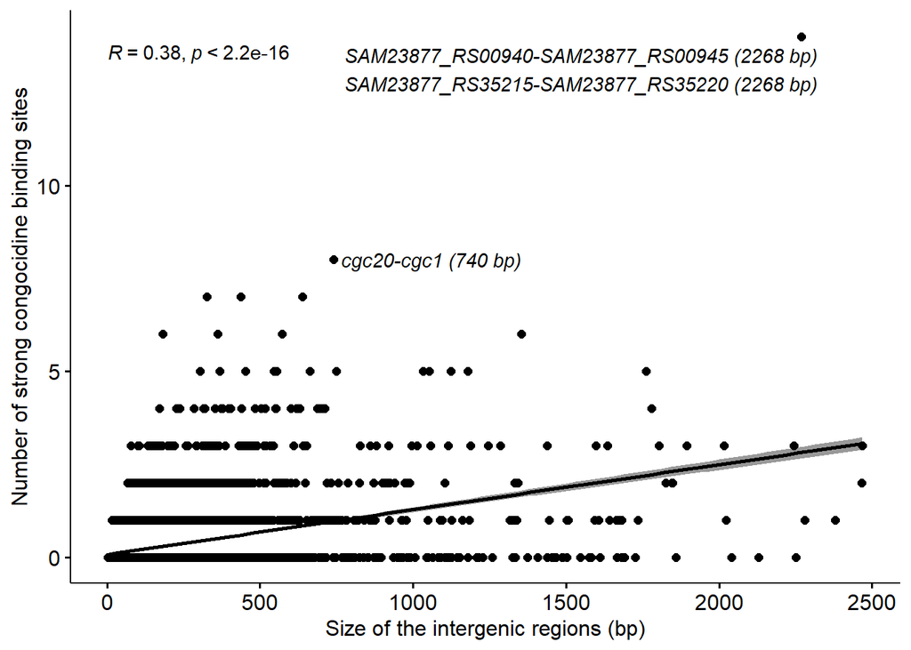

```r
df<-subset(ALL, ALL$IR_Size<2501)
library("ggpubr")
sp <-ggscatter(df, x = "IR_Size", y = "max",
          add = "reg.line", conf.int = TRUE,
          cor.coef = TRUE, cor.method = "spearman",
          xlab = "Size of the intergenic regions (bp)", ylab = "Number of strong congocidine binding sites")
sp +
  annotate ("text", x = 1060, y = 8, label = "cgc20-cgc1 (740 bp)", fontface = 'italic' )+
  annotate ("text", x = 1550, y = 13.5, label = "SAM23877_RS00940-SAM23877_RS00945 (2268 bp)", fontface = 'italic' )+
  annotate ("text", x = 1550, y = 12.75, label = "SAM23877_RS35215-SAM23877_RS35220 (2268 bp)", fontface = 'italic' )
```